# Pratical Machine Learning-Project

Spark-lin

12/3/2016

### Pratical Machine Learning-Final Project

#### 1-Project Introduction

###### 1.1-Background

Using devices such as Jawbone Up, Nike FuelBand, and Fitbit it is now possible to collect a large amount of data about personal activity relatively inexpensively. These type of devices are part of the quantified self movement – a group of enthusiasts who take measurements about themselves regularly to improve their health, to find patterns in their behavior, or because they are tech geeks. One thing that people regularly do is quantify how much of a particular activity they do, but they rarely quantify how well they do it. In this project, your goal will be to use data from accelerometers on the belt, forearm, arm, and dumbell of 6 participants. They were asked to perform barbell lifts correctly and incorrectly in 5 different ways. More information is available from the website here: http://groupware.les.inf.puc-rio.br/har (see the section on the Weight Lifting Exercise Dataset).

###### 1.2-Data Source

The training data for this project are available here:

https://d396qusza40orc.cloudfront.net/predmachlearn/pml-training.csv

The test data are available here:

https://d396qusza40orc.cloudfront.net/predmachlearn/pml-testing.csv

The data for this project come from this source: http://groupware.les.inf.puc-rio.br/har. If you use the document you create for this class for any purpose please cite them as they have been very generous in allowing their data to be used for this kind of assignment.

###### 1.3-Goal of Project

The goal of this course project is to predict the manner in which they did the exercise. This is the “classe” variable in the training set. You may use any of the other variables to predict with.

You should create a report describing how you built your model, how you used cross validation, what you think the expected out of sample error is, and rationalize why you made the choices you did. You will also use your prediction model to predict 20 different test cases.

```r
# Load required packages
library(caret)
```

```r
library(rpart)
library(rpart.plot)
library(rattle)
library(RColorBrewer)
library(randomForest)
library(knitr)
```

#### 2-Getting and cleaning data

```r
TrainUrl <- "https://d396qusza40orc.cloudfront.net/predmachlearn/pml-training.csv"
TestUrl <- "https://d396qusza40orc.cloudfront.net/predmachlearn/pml-testing.csv"

# 2.1-Load and read data
TrainData <- read.csv(url(TrainUrl), na.strings = 'NA')
TestData <- read.csv(url(TestUrl), na.strings = 'NA')

# 2.2-Create a Data partition with the Trainset (only the training data)
inTrain <- createDataPartition(TrainData$classe, p = 0.7, list = FALSE)
TrainSet <- TrainData[inTrain, ]
TestSet  <- TrainData[-inTrain, ] # don't put wrongly TestData
dim(TrainSet)
```

```
## [1] 13737   160
```

```r
dim(TestSet)
```

```
## [1] 5885  160
```

# Cleaning data

```r
# Viewing training data set
names(TrainSet)
```

```
##   [1] "X"                        "user_name"
##   [3] "raw_timestamp_part_1"     "raw_timestamp_part_2"
##   [5] "cvtd_timestamp"           "new_window"
##   [7] "num_window"               "roll_belt"
##   [9] "pitch_belt"               "yaw_belt"
##  [11] "total_accel_belt"         "kurtosis_roll_belt"
##  [13] "kurtosis_picth_belt"      "kurtosis_yaw_belt"
##  [15] "skewness_roll_belt"       "skewness_roll_belt.1"
##  [17] "skewness_yaw_belt"        "max_roll_belt"
##  [19] "max_picth_belt"           "max_yaw_belt"
##  [21] "min_roll_belt"            "min_pitch_belt"
##  [23] "min_yaw_belt"             "amplitude_roll_belt"
##  [25] "amplitude_pitch_belt"     "amplitude_yaw_belt"
##  [27] "var_total_accel_belt"     "avg_roll_belt"
##  [29] "stddev_roll_belt"         "var_roll_belt"
```

[output cut: 65 more lines]

```r
head(TrainSet)
```

```
##     X user_name raw_timestamp_part_1 raw_timestamp_part_2   cvtd_timestamp
## 1   1  carlitos           1323084231               788290 05/12/2011 11:23
## 2   2  carlitos           1323084231               808298 05/12/2011 11:23
## 3   3  carlitos           1323084231               820366 05/12/2011 11:23
## 4   4  carlitos           1323084232               120339 05/12/2011 11:23
## 7   7  carlitos           1323084232               368296 05/12/2011 11:23
## 11 11  carlitos           1323084232               500302 05/12/2011 11:23
##    new_window num_window roll_belt pitch_belt yaw_belt total_accel_belt
## 1          no         11      1.41       8.07    -94.4                3
## 2          no         11      1.41       8.07    -94.4                3
## 3          no         11      1.42       8.07    -94.4                3
## 4          no         12      1.48       8.05    -94.4                3
## 7          no         12      1.42       8.09    -94.4                3
## 11         no         12      1.45       8.18    -94.4                3
##    kurtosis_roll_belt kurtosis_picth_belt kurtosis_yaw_belt
```

[output cut: 272 more lines]

We observe that there are variables which are irrelavant for our analysis. Such as “X” and “user_variable” other NA value, Near Zero Variance (NZV) variables and ID variables

```r
TrainSet <- TrainSet[, -(1:2)]
TestSet <- TestSet[, -(1:2)]

# 2.3-Remove Near Zero variable Variance
NZV <- nearZeroVar(TrainSet)
TrainSet <- TrainSet[, -NZV]
TestSet <- TestSet[, -NZV]
dim(TrainSet)
```

```
## [1] 13737   103
```

```r
dim(TestSet )
```

```
## [1] 5885  103
```

```r
# 2.4-Remove variable that have a possibility more than 70& of value of "NA"

NA_value <- sapply(TrainSet, function(x) mean(is.na(x)))
TrainSet <- TrainSet[, (NA_value  > 0.7) == FALSE]
TestSet  <- TestSet[, (NA_value  > 0.7) == FALSE]
dim(TrainSet)
```

```
## [1] 13737    57
```

```r
dim(TestSet)
```

```
## [1] 5885   57
```

```r
# 2.5-Remove the ID variables
TrainSet <- TrainSet[, -(1:5)]
TestSet  <- TestSet[, -(1:5)]
dim(TrainSet)
```

```
## [1] 13737    52
```

```r
dim(TestSet)
```

```
## [1] 5885   52
```

#### 3-Correaltion among the variables

Let’s run a correlation analysis among the variables to see if some of varaibles are highly correlated to each other.

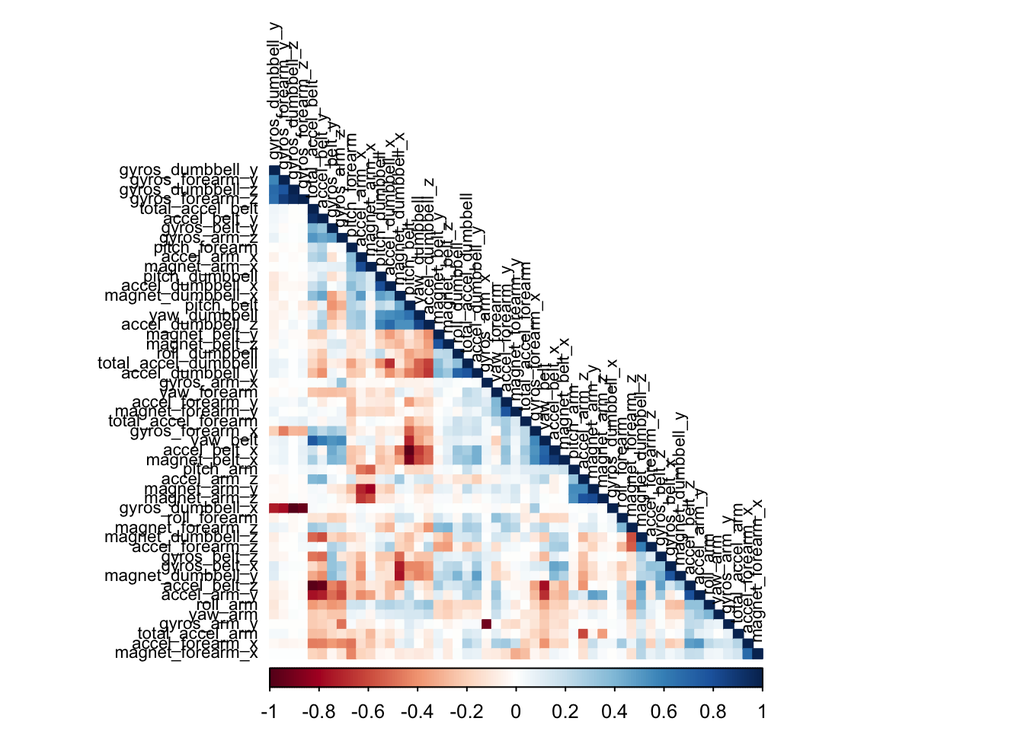

```r
library(corrplot)
corelationMatrix <- cor(TrainSet[, -52])
corrplot(corelationMatrix, order = "hclust", method = "color", type = "lower", tl.cex = 0.7, tl.col = rgb(0, 0, 0))
```

```r
# order = "FPC", refers to  the first principal component order
# order = "hclust", refers to hierarchical clustering order.
# type should only be one of “full”, “lower”, “upper” value.
```

#### 4-Prediction Model

In this part, we will use 3 prediction model to simulate the regression in the TrainSet,contrast related results and accuracy level, then select the highest accuracy methode for the quiz prediction.

The prediction methode used are: - Decision Trees - Random Forests - Generalized Boosted Regression

###### 4.1- Decision Trees Methode

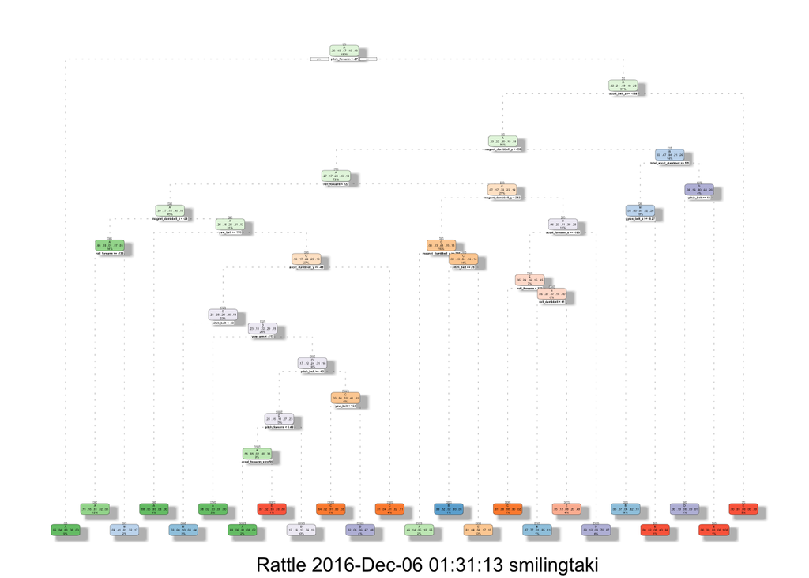

```r
set.seed(12000)
modelFit_DecisionTree <- rpart(classe ~ ., data = TrainSet, method = "class")
fancyRpartPlot(modelFit_DecisionTree)
```

```r
# Decision Tree Prediction on Test dataset
Pred_DecisionTree  <- predict(modelFit_DecisionTree, newdata = TestSet, type = "class")
ConfusionMatrix_DecisionTree <- confusionMatrix(Pred_DecisionTree, TestSet$classe)
ConfusionMatrix_DecisionTree
```

```
## Confusion Matrix and Statistics
##
##           Reference
## Prediction    A    B    C    D    E
##          A 1460  185   19   36   51
##          B   62  647   59   80  156
##          C   26   79  779  137  155
##          D  106  177  143  654  128
##          E   20   51   26   57  592
##
## Overall Statistics
##
##                Accuracy : 0.7021
##                  95% CI : (0.6903, 0.7138)
##     No Information Rate : 0.2845
##     P-Value [Acc > NIR] : < 2.2e-16
##
##                   Kappa : 0.6232
##  Mcnemar's Test P-Value : < 2.2e-16
##
## Statistics by Class:
##
##                      Class: A Class: B Class: C Class: D Class: E
## Sensitivity            0.8722   0.5680   0.7593   0.6784   0.5471
## Specificity            0.9309   0.9248   0.9183   0.8874   0.9679
## Pos Pred Value         0.8338   0.6444   0.6624   0.5414   0.7936
## Neg Pred Value         0.9482   0.8992   0.9475   0.9337   0.9047
## Prevalence             0.2845   0.1935   0.1743   0.1638   0.1839
## Detection Rate         0.2481   0.1099   0.1324   0.1111   0.1006
## Detection Prevalence   0.2975   0.1706   0.1998   0.2053   0.1268
## Balanced Accuracy      0.9015   0.7464   0.8388   0.7829   0.7575
```

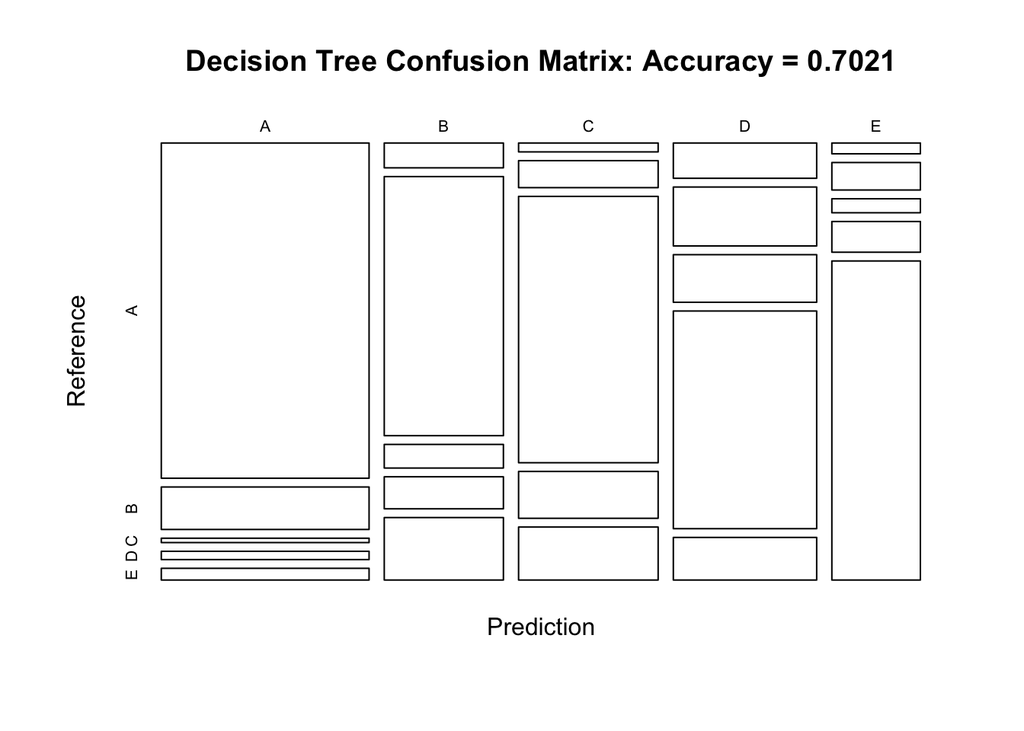

```r
# Plot Decision Tree Confusion Matrix
plot(ConfusionMatrix_DecisionTree$table, col = ConfusionMatrix_DecisionTree$byClass,
     main = paste("Decision Tree Confusion Matrix: Accuracy =",
                  round(ConfusionMatrix_DecisionTree$overall['Accuracy'], 4)))
```

###### 4.2- Random Forests Methode

```r
# Random Forests Prediction on Test dataset
set.seed(12000)
ModelFit_RanForest <- randomForest(classe~., data = TrainSet)
Pred_RanForest <- predict(ModelFit_RanForest, TestSet, type = "class")
ConfusionMatrix_RanForest <- confusionMatrix(Pred_RanForest, TestSet$classe)
ConfusionMatrix_RanForest
```

```
## Confusion Matrix and Statistics
##
##           Reference
## Prediction    A    B    C    D    E
##          A 1674    7    0    0    0
##          B    0 1131    4    0    0
##          C    0    1 1022   11    2
##          D    0    0    0  953    4
##          E    0    0    0    0 1076
##
## Overall Statistics
##
##                Accuracy : 0.9951
##                  95% CI : (0.9929, 0.9967)
##     No Information Rate : 0.2845
##     P-Value [Acc > NIR] : < 2.2e-16
##
##                   Kappa : 0.9938
##  Mcnemar's Test P-Value : NA
##
## Statistics by Class:
##
##                      Class: A Class: B Class: C Class: D Class: E
## Sensitivity            1.0000   0.9930   0.9961   0.9886   0.9945
## Specificity            0.9983   0.9992   0.9971   0.9992   1.0000
## Pos Pred Value         0.9958   0.9965   0.9865   0.9958   1.0000
## Neg Pred Value         1.0000   0.9983   0.9992   0.9978   0.9988
## Prevalence             0.2845   0.1935   0.1743   0.1638   0.1839
## Detection Rate         0.2845   0.1922   0.1737   0.1619   0.1828
## Detection Prevalence   0.2856   0.1929   0.1760   0.1626   0.1828
## Balanced Accuracy      0.9992   0.9961   0.9966   0.9939   0.9972
```

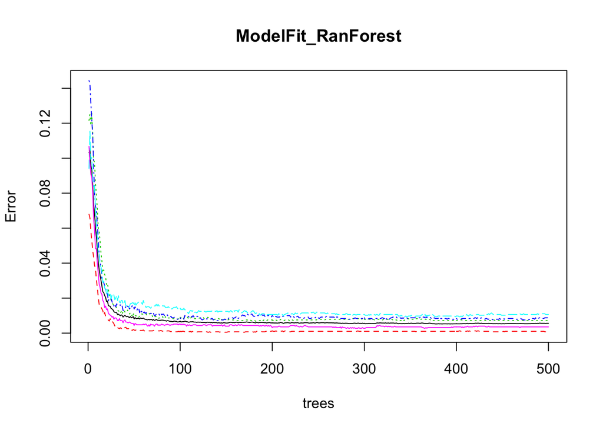

```r
# Plot ModelFit Random Forest
plot(ModelFit_RanForest)
```

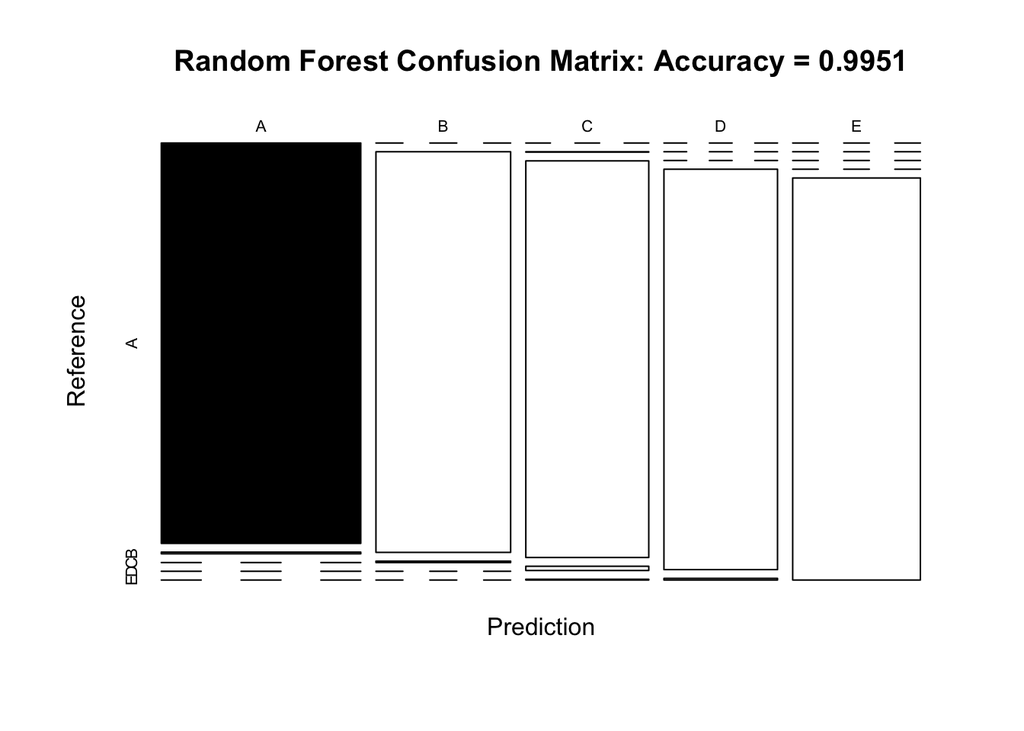

```r
# Plot Random Forest Confusion Matrix
plot(ConfusionMatrix_RanForest$table, col = ConfusionMatrix_RanForest$byClass,
     main = paste("Random Forest Confusion Matrix: Accuracy =",
                   round(ConfusionMatrix_RanForest$overall['Accuracy'], 4)))
```

###### 4.3-Generalized Boosted Regression Methode (GBM)

```r
ModelFit_Control <- trainControl(method = "repeatedcv", number = 5, repeats = 1)
ModelFit_GBM <- train(classe ~ ., data = TrainSet,
                      method = "gbm",
                      trControl = ModelFit_Control,
                      verbose = FALSE)
GBM_FinalModel <- ModelFit_GBM$finalModel
GBM_FinalModel
```

```
## A gradient boosted model with multinomial loss function.
## 150 iterations were performed.
## There were 51 predictors of which 43 had non-zero influence.
```

```r
# Generalized Boosted Regression Methode (GBM) Prediction on Test dataset
Pred_GBM <- predict(ModelFit_GBM, newdata = TestSet)
ConfusionMatrix_GBM <- confusionMatrix(Pred_GBM, TestSet$classe)
ConfusionMatrix_GBM
```

```
## Confusion Matrix and Statistics
##
##           Reference
## Prediction    A    B    C    D    E
##          A 1645   47    0    1    0
##          B   20 1056   40    3   11
##          C    7   29  972   35   11
##          D    2    1   12  917   17
##          E    0    6    2    8 1043
##
## Overall Statistics
##
##                Accuracy : 0.9572
##                  95% CI : (0.9517, 0.9622)
##     No Information Rate : 0.2845
##     P-Value [Acc > NIR] : < 2.2e-16
##
##                   Kappa : 0.9458
##  Mcnemar's Test P-Value : NA
##
## Statistics by Class:
##
##                      Class: A Class: B Class: C Class: D Class: E
## Sensitivity            0.9827   0.9271   0.9474   0.9512   0.9640
## Specificity            0.9886   0.9844   0.9831   0.9935   0.9967
## Pos Pred Value         0.9716   0.9345   0.9222   0.9663   0.9849
## Neg Pred Value         0.9931   0.9825   0.9888   0.9905   0.9919
## Prevalence             0.2845   0.1935   0.1743   0.1638   0.1839
## Detection Rate         0.2795   0.1794   0.1652   0.1558   0.1772
## Detection Prevalence   0.2877   0.1920   0.1791   0.1613   0.1799
## Balanced Accuracy      0.9856   0.9558   0.9652   0.9724   0.9803
```

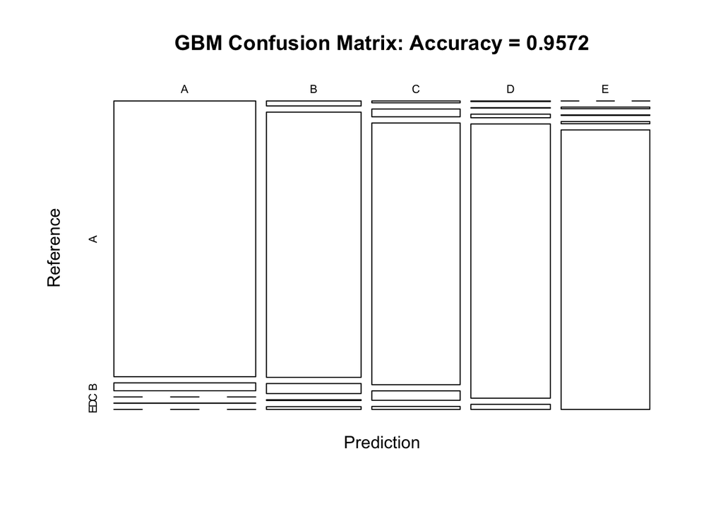

```r
# Plot Generalized Boosted Regression Methode (GBM) Confusion Matrix
plot(ConfusionMatrix_GBM$table, col = ConfusionMatrix_GBM$byClass,
     main = paste("GBM Confusion Matrix: Accuracy =",
                   round(ConfusionMatrix_GBM$overall['Accuracy'], 4)))
```

###### 4.4-Contrast the acuracy of the Three Prediction Methodes

```r
# Comparison of the Three Prediction Methodes Accuracy result
print(paste("Decision Tree Confusion Matrix: Accuracy =",
                  round(ConfusionMatrix_DecisionTree$overall['Accuracy'], 4)))
```

```
## [1] "Decision Tree Confusion Matrix: Accuracy = 0.7021"
```

```r
print(paste("Random Forest Confusion Matrix: Accuracy =",
                   round(ConfusionMatrix_RanForest$overall['Accuracy'], 4)))
```

```
## [1] "Random Forest Confusion Matrix: Accuracy = 0.9951"
```

```r
print(paste("GBM Confusion Matrix: Accuracy: Accuracy =",
                   round(ConfusionMatrix_GBM$overall['Accuracy'], 4)))
```

```
## [1] "GBM Confusion Matrix: Accuracy: Accuracy = 0.9572"
```

Therefore, we would choose the Random Forest model to precit 20 different test cases.

###### 5-Apply the the Random Forest model to precit 20 different test cases.(TestData)

```r
# Show the Extract of the first 20 results (Total morethan 8000 entries)
Pred_Test[1:20]
```

[output not shown]